# Session 6: Homework 3

2021-10-10

# 1 Youth Risk Behavior Surveillance

Every two years, the Centers for Disease Control and Prevention conduct the [Youth Risk Behavior Surveillance System (YRBSS)](https://www.cdc.gov/healthyyouth/data/yrbs/index.htm) survey, where it takes data from high schoolers (9th through 12th grade), to analyze health patterns. You will work with a selected group of variables from a random sample of observations during one of the years the YRBSS was conducted.

## 1.1 Load the data

This data is part of the `openintro` textbook and we can load and inspect it. There are observations on 13 different variables, some categorical and some numerical. The meaning of each variable can be found by bringing up the help file:

?yrbss

```r
data(yrbss)
glimpse(yrbss)
```

```
## Rows: 13,583
## Columns: 13
## $ age                      <int> 14, 14, 15, 15, 15, 15, 15, 14, 15, 15, 15, 1~
## $ gender                   <chr> "female", "female", "female", "female", "fema~
## $ grade                    <chr> "9", "9", "9", "9", "9", "9", "9", "9", "9", ~
## $ hispanic                 <chr> "not", "not", "hispanic", "not", "not", "not"~
## $ race                     <chr> "Black or African American", "Black or Africa~
## $ height                   <dbl> NA, NA, 1.73, 1.60, 1.50, 1.57, 1.65, 1.88, 1~
## $ weight                   <dbl> NA, NA, 84.4, 55.8, 46.7, 67.1, 131.5, 71.2, ~
## $ helmet_12m               <chr> "never", "never", "never", "never", "did not ~
## $ text_while_driving_30d   <chr> "0", NA, "30", "0", "did not drive", "did not~
## $ physically_active_7d     <int> 4, 2, 7, 0, 2, 1, 4, 4, 5, 0, 0, 0, 4, 7, 7, ~
## $ hours_tv_per_school_day  <chr> "5+", "5+", "5+", "2", "3", "5+", "5+", "5+",~
## $ strength_training_7d     <int> 0, 0, 0, 0, 1, 0, 2, 0, 3, 0, 3, 0, 0, 7, 7, ~
## $ school_night_hours_sleep <chr> "8", "6", "<5", "6", "9", "8", "9", "6", "<5"~
```

```r
skimr::skim(yrbss)
```

Data summary

| Name | yrbss |
| --- | --- |
| Number of rows | 13583 |
| Number of columns | 13 |
| _______________________ |  |
| Column type frequency: |  |
| character | 8 |
| numeric | 5 |
| ________________________ |  |
| Group variables | None |

**Variable type: character**

| skim_variable | n_missing | complete_rate | min | max | empty | n_unique | whitespace |
| --- | --- | --- | --- | --- | --- | --- | --- |
| gender | 12 | 1.00 | 4 | 6 | 0 | 2 | 0 |
| grade | 79 | 0.99 | 1 | 5 | 0 | 5 | 0 |
| hispanic | 231 | 0.98 | 3 | 8 | 0 | 2 | 0 |
| race | 2805 | 0.79 | 5 | 41 | 0 | 5 | 0 |
| helmet_12m | 311 | 0.98 | 5 | 12 | 0 | 6 | 0 |
| text_while_driving_30d | 918 | 0.93 | 1 | 13 | 0 | 8 | 0 |
| hours_tv_per_school_day | 338 | 0.98 | 1 | 12 | 0 | 7 | 0 |
| school_night_hours_sleep | 1248 | 0.91 | 1 | 3 | 0 | 7 | 0 |

**Variable type: numeric**

| skim_variable | n_missing | complete_rate | mean | sd | p0 | p25 | p50 | p75 | p100 | hist |
| --- | --- | --- | --- | --- | --- | --- | --- | --- | --- | --- |
| age | 77 | 0.99 | 16.16 | 1.26 | 12.00 | 15.0 | 16.00 | 17.00 | 18.00 | ▁▂▅▅▇ |
| height | 1004 | 0.93 | 1.69 | 0.10 | 1.27 | 1.6 | 1.68 | 1.78 | 2.11 | ▁▅▇▃▁ |
| weight | 1004 | 0.93 | 67.91 | 16.90 | 29.94 | 56.2 | 64.41 | 76.20 | 180.99 | ▆▇▂▁▁ |
| physically_active_7d | 273 | 0.98 | 3.90 | 2.56 | 0.00 | 2.0 | 4.00 | 7.00 | 7.00 | ▆▂▅▃▇ |
| strength_training_7d | 1176 | 0.91 | 2.95 | 2.58 | 0.00 | 0.0 | 3.00 | 5.00 | 7.00 | ▇▂▅▂▅ |

Before you carry on with your analysis, it’s is always a good idea to check with `skimr::skim()` to get a feel for missing values, summary statistics of numerical variables, and a very rough histogram.

## 1.2 Exploratory Data Analysis

You will first start with analyzing the `weight` of participants in kilograms. Using visualization and summary statistics, describe the distribution of weights. How many observations are we missing weights from?

```r
favstats(~weight, data = yrbss)
```

```
##   min   Q1 median   Q3 max mean   sd     n missing
##  29.9 56.2   64.4 76.2 181 67.9 16.9 12579    1004
```

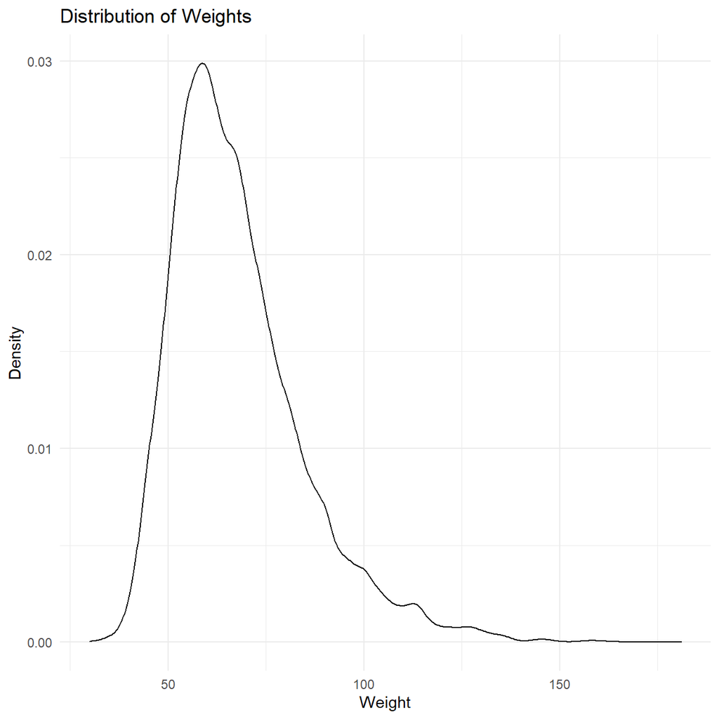

```r
ggplot(yrbss, aes(x = weight))+
  geom_density()+
  theme_minimal()+
  labs (
    title = "Distribution of Weights",
    x = "Weight",
    y = "Density"
  )+
NULL
```

There are 1004 observations that are missing from the variable“weight”.

Next, consider the possible relationship between a high schooler’s weight and their physical activity. Plotting the data is a useful first step because it helps us quickly visualize trends, identify strong associations, and develop research questions.

Let’s create a new variable in the dataframe `yrbss`, called `physical_3plus` , which will be `yes` if they are physically active for at least 3 days a week, and `no` otherwise. You may also want to calculate the number and % of those who are and are not active for more than 3 days. RUse the `count()` function and see if you get the same results as `group_by()... summarise()`

```r
yrbss <- yrbss %>%
  filter(!is.na(physically_active_7d)) %>%
  mutate(physical_3plus = ifelse(physically_active_7d >=3, "yes", "no"))

count(yrbss, physical_3plus)
```

```
## # A tibble: 2 x 2
##   physical_3plus     n
##   <chr>          <int>
## 1 no              4404
## 2 yes             8906
```

```r
table(yrbss$physical_3plus)/length(yrbss$physical_3plus)
```

```
##
##    no   yes
## 0.331 0.669
```

```r
yrbss_1 <- yrbss %>%
  group_by(physical_3plus) %>%
  summarize(count_physical_3plus=n()) %>%
  mutate(percentage_physical_3plus = round(count_physical_3plus/sum(count_physical_3plus),3))
view(yrbss_1)
```

The two functions generate different results, however, when we apply the filter function to eliminate the NA values of the variable physically_active_7d, the two functions generate the same results.

Can you provide a 95% confidence interval for the population proportion of high schools that are *NOT* active 3 or more days per week?

```r
prop.test(4404, 13310, conf.level = 0.95)
```

```
##
##  1-sample proportions test with continuity correction
##
## data:  4404 out of 13310
## X-squared = 1522, df = 1, p-value <2e-16
## alternative hypothesis: true p is not equal to 0.5
## 95 percent confidence interval:
##  0.323 0.339
## sample estimates:
##     p
## 0.331
```

Make a boxplot of `physical_3plus` vs. `weight`. Is there a relationship between these two variables? What did you expect and why?

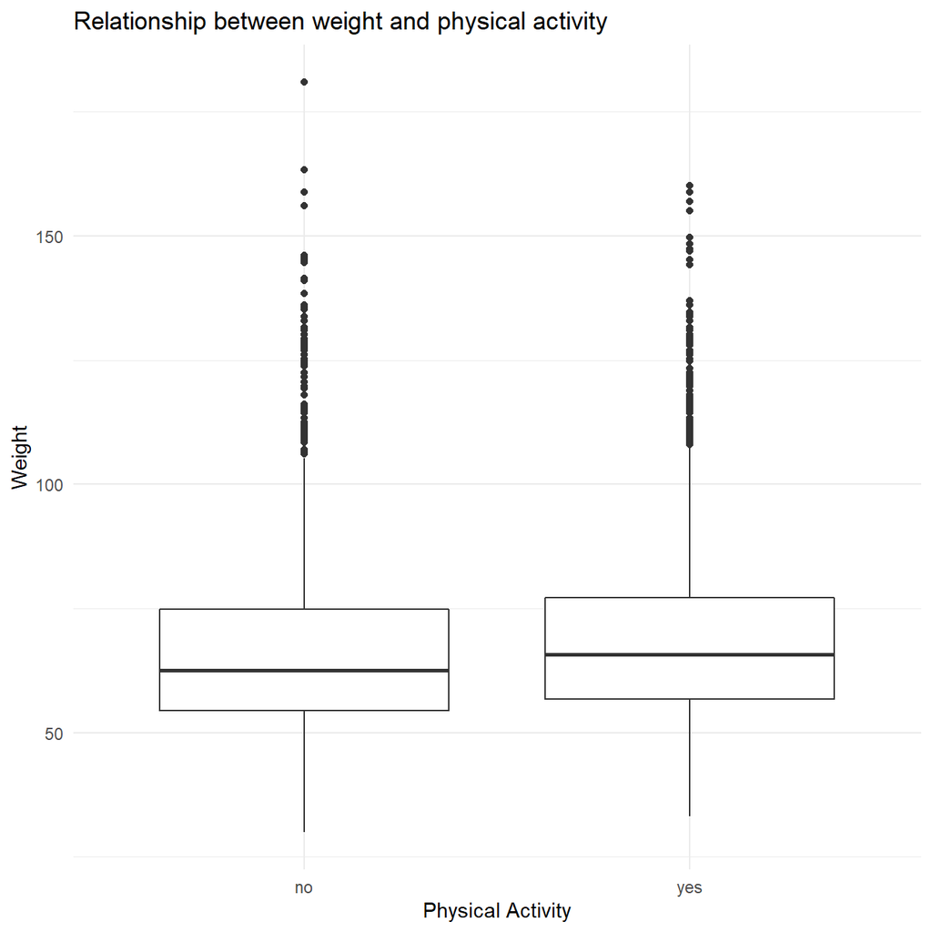

```r
ggplot(yrbss, aes(x = physical_3plus, y = weight))+
  geom_boxplot()+
  theme_minimal()+
  labs (
    title = "Relationship between weight and physical activity",
    x = "Physical Activity",
    y = "Weight"
  )
```

```r
NULL
```

We can observe a postive relationship between the weight and physical_3plus, we can say from the plot that, the more physically active the higher weight on average. Also, what can be observed is that, for the people with high level of physical activity, the weight is more evenly distributed without extreme weight that is higher than average. This could be explained as although the people who are taking more exercise generally have a better body shape, they do have more muscles compared to people who seldom done any exercises, and we know that the muscles are heavier compared to the fat.

## 1.3 Confidence Interval

Boxplots show how the medians of the two distributions compare, but we can also compare the means of the distributions using either a confidence interval or a hypothesis test. Note that when we calculate the mean, SD, etc. weight in these groups using the mean function, we must ignore any missing values by setting the `na.rm = TRUE`.

```r
formula_ci <- yrbss %>%
  filter(!is.na(weight)) %>%
  group_by(physical_3plus) %>%
  summarize(mean_weight = mean(weight),
            sd_weight = sd(weight),
            count = n(),
            t_critical = qt(0.975, count-1),
            se_weight = sd(weight)/sqrt(count),
            margin_of_error = t_critical * se_weight,
            weight_low = mean_weight - margin_of_error,
            weight_high = mean_weight + margin_of_error
            )
view(formula_ci)
```

There is an observed difference of about 1.77kg (68.44 - 66.67), and we notice that the two confidence intervals do not overlap. It seems that the difference is at least 95% statistically significant. Let us also conduct a hypothesis test.

## 1.4 Hypothesis test with formula

Write the null and alternative hypotheses for testing whether mean weights are different for those who exercise at least 3 times a week and those who don’t. Null hypothesis: No signidicant difference in mean weights for those who exercise at least 3 times a week and those who don’t Alternative hypothesis: Significant difference in mean weights for those who exercise at least 3 times a week and those who don’t.

```r
t.test(weight ~ physical_3plus, data = yrbss)
```

```
##
##  Welch Two Sample t-test
##
## data:  weight by physical_3plus
## t = -5, df = 7479, p-value = 9e-08
## alternative hypothesis: true difference in means between group no and group yes is not equal to 0
## 95 percent confidence interval:
##  -2.42 -1.12
## sample estimates:
##  mean in group no mean in group yes
##              66.7              68.4
```

## 1.5 Hypothesis test with `infer`

Next, we will introduce a new function, `hypothesize`, that falls into the infer workflow. You will use this method for conducting hypothesis tests.

But first, we need to initialize the test, which we will save as `obs_diff`.

```r
obs_diff <- yrbss %>%
  specify(weight ~ physical_3plus) %>%
  calculate(stat = "diff in means", order = c("yes", "no"))
```

Notice how you can use the functions specify and calculate again like you did for calculating confidence intervals. Here, though, the statistic you are searching for is the difference in means, with the order being yes - no != 0.

After you have initialized the test, you need to simulate the test on the null distribution, which we will save as null.

```r
null_dist <- yrbss %>%
  # specify variables
  specify(weight ~ physical_3plus) %>%

  # assume independence, i.e, there is no difference
  hypothesize(null = "independence") %>%

  # generate 1000 reps, of type "permute"
  generate(reps = 1000, type = "permute") %>%

  # calculate statistic of difference, namely "diff in means"
  calculate(stat = "diff in means", order = c("yes", "no"))
```

Here, `hypothesize` is used to set the null hypothesis as a test for independence, i.e., that there is no difference between the two population means. In one sample cases, the null argument can be set to *point* to test a hypothesis relative to a point estimate.

Also, note that the `type` argument within generate is set to permute, which is the argument when generating a null distribution for a hypothesis test.

We can visualize this null distribution with the following code:

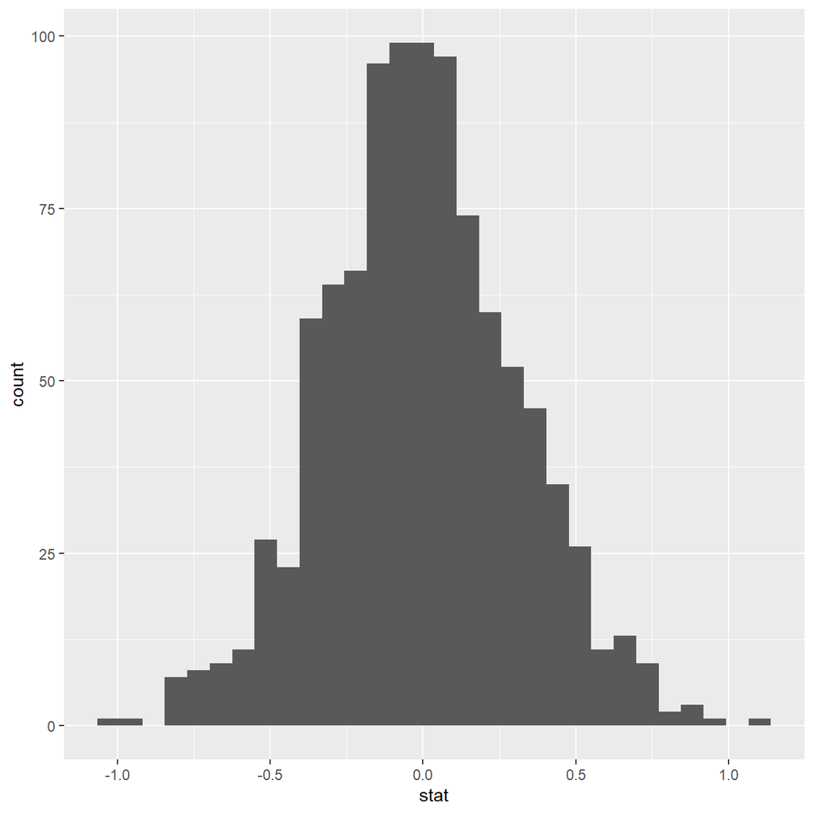

```r
ggplot(data = null_dist, aes(x = stat)) +
  geom_histogram()
```

Now that the test is initialized and the null distribution formed, we can visualise to see how many of these null permutations have a difference of at least `obs_stat` of 1.77?

We can also calculate the p-value for your hypothesis test using the function `infer::get_p_value()`.

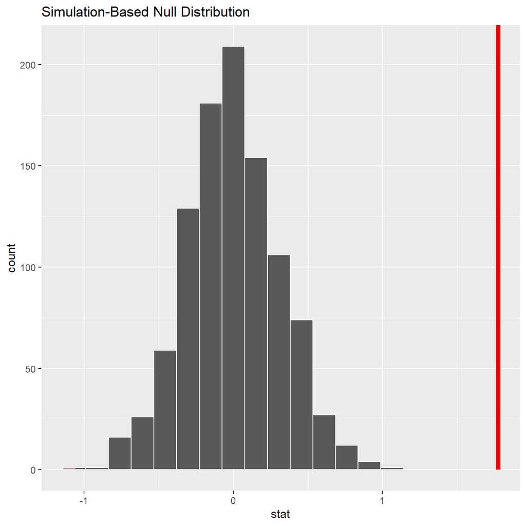

```r
null_dist %>% visualize() +
  shade_p_value(obs_stat = obs_diff, direction = "two-sided")
```

```r
null_dist %>%
  get_p_value(obs_stat = obs_diff, direction = "two_sided")
```

```
## # A tibble: 1 x 1
##   p_value
##     <dbl>
## 1       0
```

This the standard workflow for performing hypothesis tests.

# 2 IMDB ratings: Differences between directors

I would like you to explore whether the mean IMDB rating for Steven Spielberg and Tim Burton are the same or not. I have already calculated the confidence intervals for the mean ratings of these two directors and as you can see they overlap.

```r
movies <- read_csv(here::here("data", "movies.csv"))
glimpse(movies)
```

```
## Rows: 2,961
## Columns: 11
## $ title               <chr> "Avatar", "Titanic", "Jurassic World", "The Avenge~
## $ genre               <chr> "Action", "Drama", "Action", "Action", "Action", "~
## $ director            <chr> "James Cameron", "James Cameron", "Colin Trevorrow~
## $ year                <dbl> 2009, 1997, 2015, 2012, 2008, 1999, 1977, 2015, 20~
## $ duration            <dbl> 178, 194, 124, 173, 152, 136, 125, 141, 164, 93, 1~
## $ gross               <dbl> 7.61e+08, 6.59e+08, 6.52e+08, 6.23e+08, 5.33e+08, ~
## $ budget              <dbl> 2.37e+08, 2.00e+08, 1.50e+08, 2.20e+08, 1.85e+08, ~
## $ cast_facebook_likes <dbl> 4834, 45223, 8458, 87697, 57802, 37723, 13485, 920~
## $ votes               <dbl> 886204, 793059, 418214, 995415, 1676169, 534658, 9~
## $ reviews             <dbl> 3777, 2843, 1934, 2425, 5312, 3917, 1752, 1752, 35~
## $ rating              <dbl> 7.9, 7.7, 7.0, 8.1, 9.0, 6.5, 8.7, 7.5, 8.5, 7.2, ~
```

*Null Hypothesis:* Both Directors (Steven Spielberg & Tim Burton) have same average ratings on IMDB *Alternative Hypothesis:* The two directors **do not** have the same average ratings.

```r
movies_new <- movies %>%
  filter(director %in% c("Steven Spielberg","Tim Burton"))

t.test(rating ~ director, data = movies_new)
```

```
##
##  Welch Two Sample t-test
##
## data:  rating by director
## t = 3, df = 31, p-value = 0.01
## alternative hypothesis: true difference in means between group Steven Spielberg and group Tim Burton is not equal to 0
## 95 percent confidence interval:
##  0.16 1.13
## sample estimates:
## mean in group Steven Spielberg       mean in group Tim Burton
##                           7.57                           6.93
```

```r
imdb_ratings <- movies_new %>%
  group_by(director) %>%
  summarise(mean_rating = mean(rating),
            count = n(),
            margin_of_error = qt(0.975, count-1)*sd(rating)/sqrt(count),
            lower = mean_rating - margin_of_error,
            upper = mean_rating + margin_of_error)
```

The p value is 0.01 (less than 0.05), so we can reject the null hypothesis.

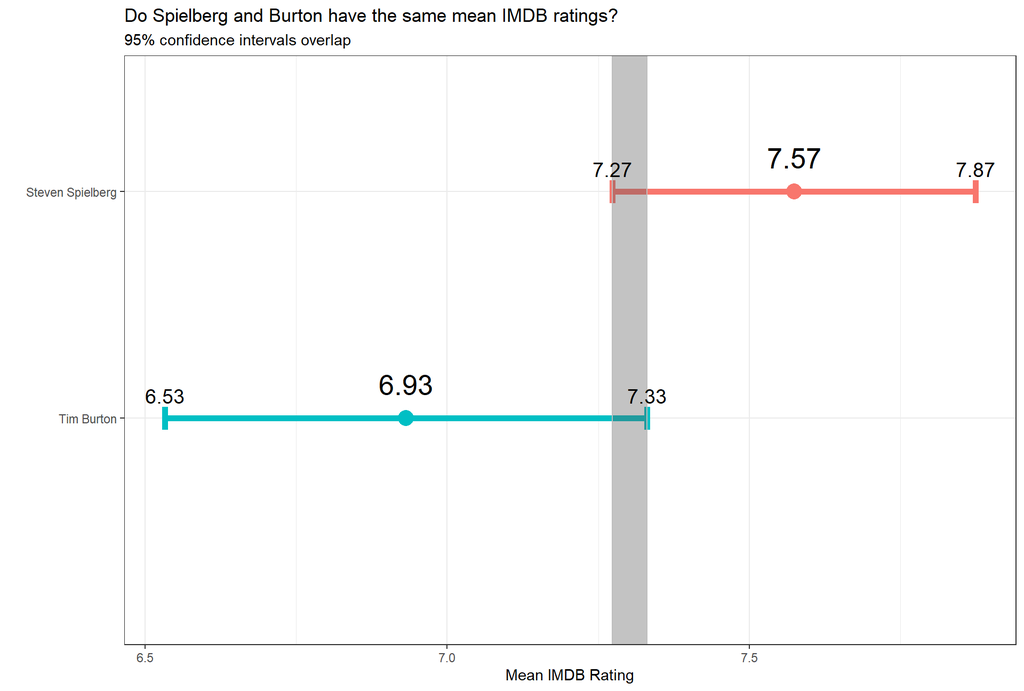

```r
ggplot(imdb_ratings,aes(x = mean_rating, y = reorder(director, desc(director)), colour = director)) +
  geom_point(size = 5) +
  geom_errorbar(aes(xmin = lower, xmax = upper), width = 0.1, size = 2) +
  geom_rect(aes(xmin=max(lower), xmax=min(upper), ymin=0, ymax=Inf),
            color='grey', alpha=0.2) +

  geom_text(aes(label = round(mean_rating, digits = 2), x = mean_rating),
            size = 7, colour = "black", nudge_y = 0.15) +
  geom_text(aes(label = round(lower, digits = 2), x = lower),
            size = 5, colour = "black",nudge_y = 0.1) +
  geom_text(aes(label = round(upper, digits = 2), x = upper),
            size = 5, colour = "black",nudge_y = 0.1) +

  labs(title = "Do Spielberg and Burton have the same mean IMDB ratings?",
       subtitle = "95% confidence intervals overlap" ,
       x = "Mean IMDB Rating", y = " ") +
  theme_bw() +
  theme(legend.position = "none")
```

The average rating for Steven Spielberg is higher than the average ratings for Tim Burton (at a 95% confidence interval). Thus we can reject the Null Hypothesis.

Using infer package:

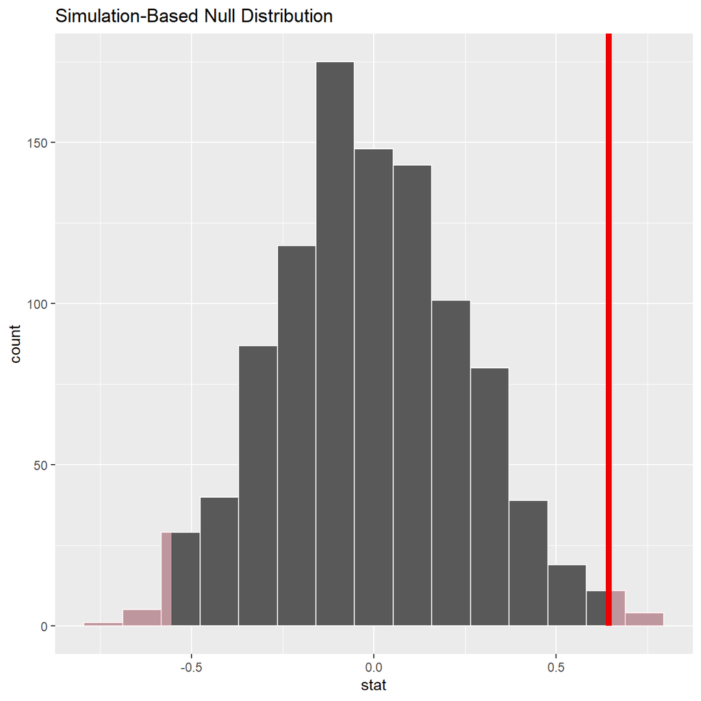

```r
obs_diff_movies <- movies_new %>%
  specify(rating ~ director) %>%
  calculate(stat = "diff in means", order = c("Steven Spielberg", "Tim Burton"))

null_dist_movies <- movies_new %>%
  specify(rating ~ director) %>%
  hypothesize(null = "independence") %>%
  generate(reps = 1000, type = "permute") %>%
  calculate(stat = "diff in means", order = c("Steven Spielberg", "Tim Burton"))

null_dist_movies %>% visualize() +
  shade_p_value(obs_stat = obs_diff_movies, direction = "two-sided")
```

```r
null_dist_movies %>%
  get_p_value(obs_stat = obs_diff_movies, direction = "two_sided")
```

```
## # A tibble: 1 x 1
##   p_value
##     <dbl>
## 1   0.014
```

# 3 Omega Group plc- Pay Discrimination

At the last board meeting of Omega Group Plc., the headquarters of a large multinational company, the issue was raised that women were being discriminated in the company, in the sense that the salaries were not the same for male and female executives. A quick analysis of a sample of 50 employees (of which 24 men and 26 women) revealed that the average salary for men was about 8,700 higher than for women. This seemed like a considerable difference, so it was decided that a further analysis of the company salaries was warranted.

## 3.1 Loading the data

```r
omega <- read_csv(here::here("data", "omega.csv"))
glimpse(omega) # examine the data frame
```

```
## Rows: 50
## Columns: 3
## $ salary     <dbl> 81894, 69517, 68589, 74881, 65598, 76840, 78800, 70033, 635~
## $ gender     <chr> "male", "male", "male", "male", "male", "male", "male", "ma~
## $ experience <dbl> 16, 25, 15, 33, 16, 19, 32, 34, 1, 44, 7, 14, 33, 19, 24, 3~
```

Summary statistics:

## 3.2 Relationship Salary - Gender ?

```r
# Summary Statistics of salary by gender
mosaic::favstats (salary ~ gender, data=omega)
```

```
##   gender   min    Q1 median    Q3   max  mean   sd  n missing
## 1 female 47033 60338  64618 70033 78800 64543 7567 26       0
## 2   male 54768 68331  74675 78568 84576 73239 7463 24       0
```

```r
# Dataframe with two rows (male-female) and having as columns gender, mean, SD, sample size,

gender_data_frame <- omega %>%
  group_by(gender) %>%
  summarise(mean = mean(salary),sd = sd(salary),size = n())


# the t-critical value, the standard error, the margin of error,
gender_data_frame <- gender_data_frame %>%
  mutate(tcritical = qt(p=0.05/2,df=size-1,lower.tail = FALSE),standard_error=sd/sqrt(size),margin_of_error=tcritical*standard_error)

# and the low/high endpoints of a 95% confidence interval

gender_data_frame <- gender_data_frame %>%
  mutate(low=mean-tcritical*standard_error,high=mean+tcritical*standard_error)

print(gender_data_frame)
```

```
## # A tibble: 2 x 9
##   gender   mean    sd  size tcritical standard_error margin_of_error    low
##   <chr>   <dbl> <dbl> <int>     <dbl>          <dbl>           <dbl>  <dbl>
## 1 female 64543. 7567.    26      2.06          1484.           3056. 61486.
## 2 male   73239. 7463.    24      2.07          1523.           3151. 70088.
## # ... with 1 more variable: high <dbl>
```

We can see that for women, the salary ranges from 61486 to 67599 while for men it ranges from 70088 to 76390 with 95% confidence. Since these ranges have no common point, it seems that there really is a significant difference between the salaries.

Hypothesis testing: null hypothesis = the mean difference in salaries is zero, or on average, men and women make the same amount of money.

```r
# hypothesis testing using t.test()

t.test(salary~gender,data=omega)
```

```
##
##  Welch Two Sample t-test
##
## data:  salary by gender
## t = -4, df = 48, p-value = 2e-04
## alternative hypothesis: true difference in means between group female and group male is not equal to 0
## 95 percent confidence interval:
##  -12973  -4420
## sample estimates:
## mean in group female   mean in group male
##                64543                73239
```

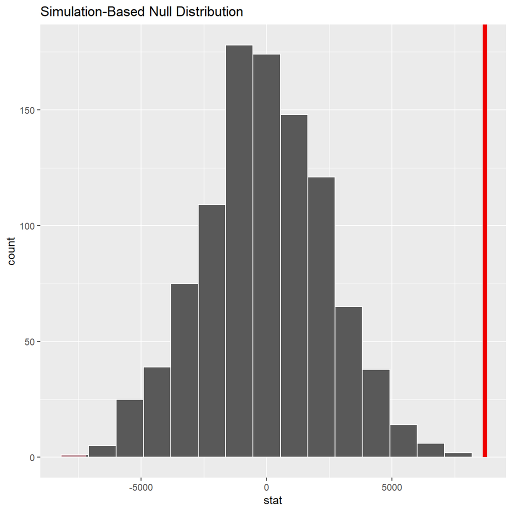

```r
# hypothesis testing using infer package
set.seed(1234)
mean_diff_df <- omega %>%
  specify(salary~gender) %>%
  hypothesize(null="independence") %>%
  generate(reps=1000,type="permute") %>%
  calculate(stat="diff in means",order = c("male","female"))

observed_statistic <- omega %>%
  specify(salary~gender) %>%
  calculate(stat="diff in means",order = c("male","female"))

mean_diff_df %>%
  visualize()+
  shade_p_value(observed_statistic, direction = "two-sided")
```

```r
mean_diff_df %>%
  get_p_value(obs_stat = observed_statistic, direction = "two-sided")
```

```
## # A tibble: 1 x 1
##   p_value
##     <dbl>
## 1       0
```

Both t-tests show the same output, p-value is almost 0. That means the we should reject the null hypothesis which stated that salary of male and female workers were the same. There is definitely a difference between the means.

## 3.3 Relationship Experience - Gender?

At the board meeting, someone raised the issue that there was indeed a substantial difference between male and female salaries, but that this was attributable to other reasons such as differences in experience. A questionnaire send out to the 50 executives in the sample reveals that the average experience of the men is approximately 21 years, whereas the women only have about 7 years experience on average (see table below).

```r
# Summary Statistics of salary by gender
favstats (experience ~ gender, data=omega)
```

```
##   gender min    Q1 median   Q3 max  mean    sd  n missing
## 1 female   0  0.25    3.0 14.0  29  7.38  8.51 26       0
## 2   male   1 15.75   19.5 31.2  44 21.12 10.92 24       0
```

```r
# hypothesis testing using t.test()

t.test(experience~gender,data=omega)
```

```
##
##  Welch Two Sample t-test
##
## data:  experience by gender
## t = -5, df = 43, p-value = 1e-05
## alternative hypothesis: true difference in means between group female and group male is not equal to 0
## 95 percent confidence interval:
##  -19.35  -8.13
## sample estimates:
## mean in group female   mean in group male
##                 7.38                21.12
```

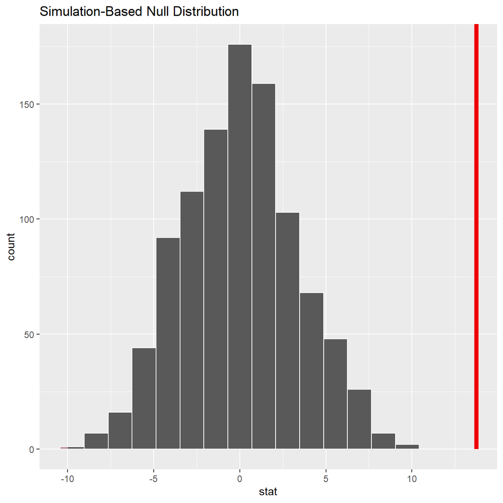

```r
# hypothesis testing using infer package
set.seed(1234)
mean_diff_exp_df <- omega %>%
  specify(experience~gender) %>%
  hypothesize(null="independence") %>%
  generate(reps=1000,type="permute") %>%
  calculate(stat="diff in means",order = c("male","female"))

observed_statistic <- omega %>%
  specify(experience~gender) %>%
  calculate(stat="diff in means",order = c("male","female"))

mean_diff_exp_df %>%
  visualize()+
  shade_p_value(observed_statistic, direction = "two-sided")
```

```r
mean_diff_exp_df %>%
  get_p_value(obs_stat = observed_statistic, direction = "two-sided")
```

```
## # A tibble: 1 x 1
##   p_value
##     <dbl>
## 1       0
```

There is also a significant difference between the experiences of males and females since p-value is almost zero. This conclusion endangers the previous conclusion that there was a difference between male and female salaries. But now we see that this difference can be caused by the experience of workers.

## 3.4 Relationship Salary - Experience ?

Someone at the meeting argues that clearly, a more thorough analysis of the relationship between salary and experience is required before any conclusion can be drawn about whether there is any gender-based salary discrimination in the company.

Analyse the relationship between salary and experience. Draw a scatterplot to visually inspect the data

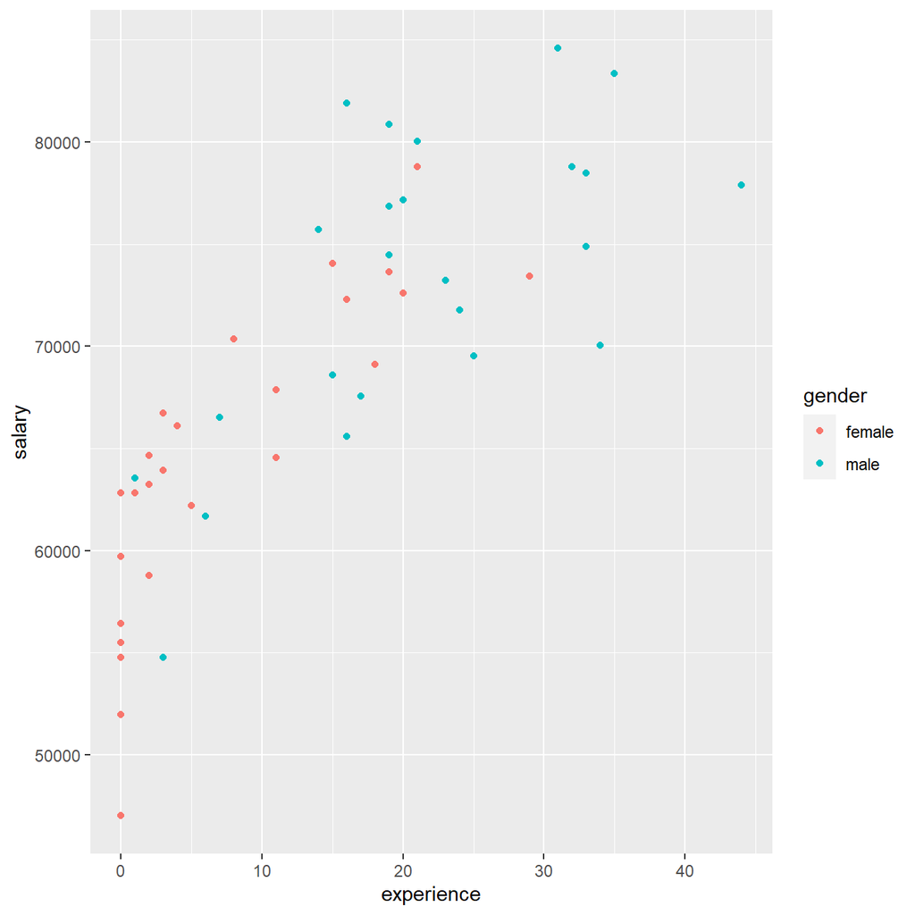

```r
omega %>%
  ggplot(aes(x=experience,y=salary,col=gender))+
  geom_point()
```

## 3.5 Check correlations between the data

You can use `GGally:ggpairs()` to create a scatterplot and correlation matrix. Essentially, we change the order our variables will appear in and have the dependent variable (Y), salary, as last in our list. We then pipe the dataframe to `ggpairs()` with `aes` arguments to colour by `gender` and make ths plots somewhat transparent (`alpha = 0.3`).

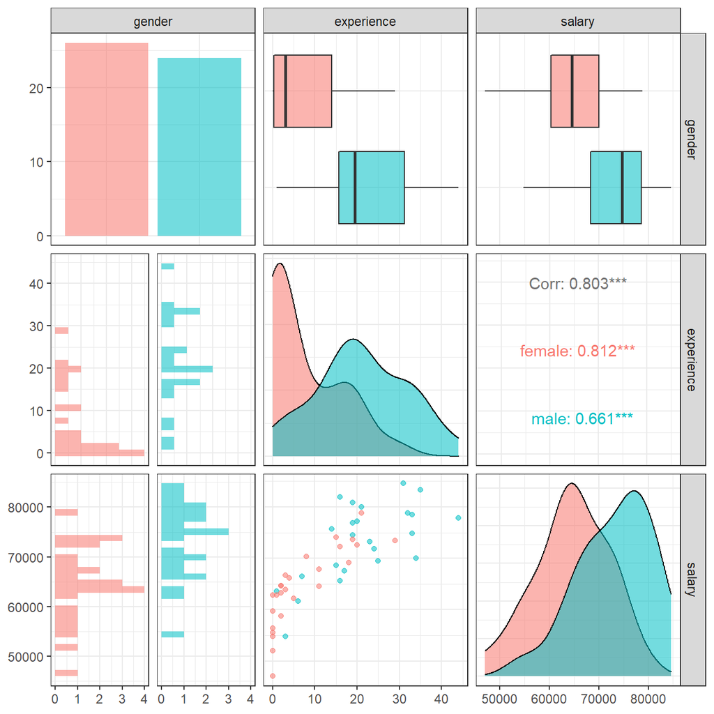

```r
omega %>%
  select(gender, experience, salary) %>% #order variables they will appear in ggpairs()
  ggpairs(aes(colour=gender, alpha = 0.3))+
  theme_bw()
```

> Look at the salary vs experience scatterplot. What can you infer from this plot? Explain in a couple of sentences

The scatter plot and the correlation figure of 0.8 shows that salary is highly explained by the experience of a worker. Since there is significant difference between the experience of genders, the salary difference is explained by the experience.

# 4 Challenge 1: Yield Curve inversion

```r
#Load data
yield_curve <- read_csv(here::here("data", "yield_curve.csv"))
```

## 4.1 Yields on US rates by duration since 1960

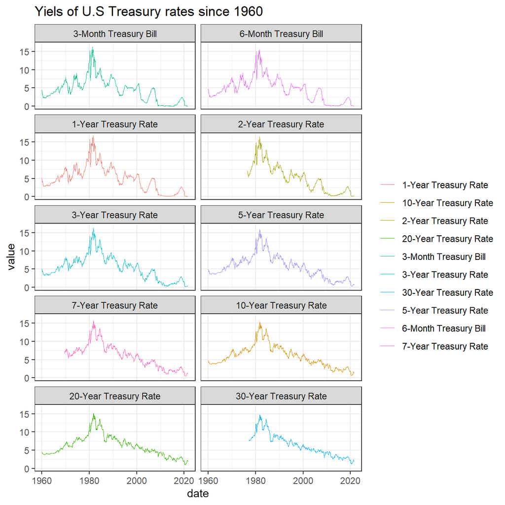

```r
#PLotting a graph of rates since 1960
yield_curve %>%
  ggplot(aes(x=date,y=value,color = duration))+
  geom_line(size=0.2)+

#Faceting the graphs by duration
facet_wrap(~ factor(duration,
                        levels = c("3-Month Treasury Bill",
                                   "6-Month Treasury Bill",
                                   "1-Year Treasury Rate",
                                   "2-Year Treasury Rate",
                                   "3-Year Treasury Rate",
                                   "5-Year Treasury Rate",
                                   "7-Year Treasury Rate",
                                   "10-Year Treasury Rate",
                                   "20-Year Treasury Rate",
                                   "30-Year Treasury Rate")),
               ncol = 2)+
  theme_bw()+
  labs(title="Yiels of U.S Treasury rates since 1960",color="")
```

## 4.2 Monthly yields on US rates by duration since 1999 on a year-by-year basis

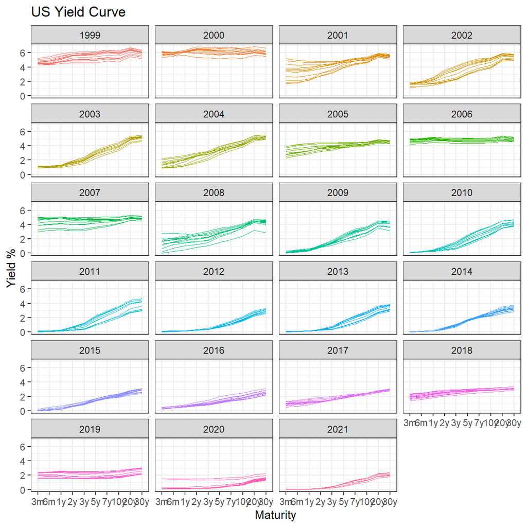

```r
yield_curve %>%

  #Deleting the years previous to 1999
  filter(year(date)>=1999) %>%

  #Plotting US rates by duration since 1999
  ggplot(aes(x=maturity,y=value,group= date,color=as.factor(year(date) )))+
  geom_line(size=0.2)+

  #Faceting by years
  facet_wrap(~year(date), ncol=4)+

  #Reordering the x axis
  scale_x_discrete(limits=c('3m','6m','1y','2y','3y','5y','7y','10y','20y','30y'))+
  theme_bw()+
  theme(legend.position = "none")+
  labs(title="US Yield Curve",x="Maturity",y="Yield %",caption=NULL)
```

### 4.2.1 3-month and 10-year yields since 1999

[figure not shown]

```r
# get US recession dates after 1946 from Wikipedia
# https://en.wikipedia.org/wiki/List_of_recessions_in_the_United_States

recessions <- tibble(
  from = c("1948-11-01", "1953-07-01", "1957-08-01", "1960-04-01", "1969-12-01", "1973-11-01", "1980-01-01","1981-07-01", "1990-07-01", "2001-03-01", "2007-12-01","2020-02-01"),
  to = c("1949-10-01", "1954-05-01", "1958-04-01", "1961-02-01", "1970-11-01", "1975-03-01", "1980-07-01", "1982-11-01", "1991-03-01", "2001-11-01", "2009-06-01", "2020-04-30")
  )  %>%
  mutate(From = ymd(from),
         To=ymd(to),
         duration_days = To-From)
recessions
```

```
## # A tibble: 12 x 5
##    from       to         From       To         duration_days
##    <chr>      <chr>      <date>     <date>     <drtn>
##  1 1948-11-01 1949-10-01 1948-11-01 1949-10-01 334 days
##  2 1953-07-01 1954-05-01 1953-07-01 1954-05-01 304 days
##  3 1957-08-01 1958-04-01 1957-08-01 1958-04-01 243 days
##  4 1960-04-01 1961-02-01 1960-04-01 1961-02-01 306 days
##  5 1969-12-01 1970-11-01 1969-12-01 1970-11-01 335 days
##  6 1973-11-01 1975-03-01 1973-11-01 1975-03-01 485 days
##  7 1980-01-01 1980-07-01 1980-01-01 1980-07-01 182 days
##  8 1981-07-01 1982-11-01 1981-07-01 1982-11-01 488 days
##  9 1990-07-01 1991-03-01 1990-07-01 1991-03-01 243 days
## 10 2001-03-01 2001-11-01 2001-03-01 2001-11-01 245 days
## 11 2007-12-01 2009-06-01 2007-12-01 2009-06-01 548 days
## 12 2020-02-01 2020-04-30 2020-02-01 2020-04-30  89 days
```

[figure not shown]

```r
#Plotting final graph

#Changing the format from long to wide in order to compute the spread and plot it
yield_wide <- yield_curve %>%

  #deleting two columns that prevent the dataframe to be converting into long format
  select(-series_id) %>%
  select(-duration) %>%

  #Creating the columns for each maturity and assigning the respective yields
  pivot_wider(names_from = "maturity",values_from = "value") %>%

  #Computing the spread
  mutate(spread =`10y`-`3y`)

  #Deleting the receissions  data previous to 1960
  recessions <- recessions %>%
  filter(year(From)>=1960)

  #Creating the plot
  ggplot()+
  #Plotting the spread line
  geom_line(data=yield_wide,aes(x=date,y=spread),size=0.2)+

  #Plotting the blue and red ribbons
  geom_ribbon(data=yield_wide,aes(x=date, ymin = 0, ymax = spread, fill = spread > 0),alpha=0.2)+
  scale_fill_manual(values=c("red","blue"), name="fill")+

  #Plotting the grey shades
  geom_rect(data = data.frame(x1=recessions$From, x2=recessions$To, y1=-Inf, y2=Inf),aes(xmin=x1,xmax=x2,ymin=y1,ymax=y2),alpha=0.2)+
  #Deleting legend
  guides(fill=FALSE)+
  labs(title="Yield Curve Inversion: 10-year minus 3-month US. Tresury rates", subtitle="Difference in % points, monthly averages. Shaded areas correspond to recession",y="Difference(10 year- 3month) yield in %")+
  theme_bw()
```

# 5 Challenge 2: GDP components over time and among countries

At the risk of oversimplifying things, the main components of gross domestic product, GDP are personal consumption (C), business investment (I), government spending (G) and net exports (exports - imports). You can read more about GDP and the different approaches in calculating at the [Wikipedia GDP page](https://en.wikipedia.org/wiki/Gross_domestic_product).

The GDP data we will look at is from the [United Nations’ National Accounts Main Aggregates Database](https://unstats.un.org/unsd/snaama/Downloads), which contains estimates of total GDP and its components for all countries from 1970 to today. We will look at how GDP and its components have changed over time, and compare different countries and how much each component contributes to that country’s GDP. The file we will work with is [GDP and its breakdown at constant 2010 prices in US Dollars](http://unstats.un.org/unsd/amaapi/api/file/6) and it has already been saved in the Data directory. Have a look at the Excel file to see how it is structured and organised

```r
UN_GDP_data  <-  read_excel(here::here("data", "Download-GDPconstant-USD-countries.xls"), # Excel filename
                sheet="Download-GDPconstant-USD-countr", # Sheet name
                skip=2) # Number of rows to skip
```

Tidy data:

```r
tidy_GDP_data  <-  gather(UN_GDP_data, Year, GDP_components, "1970":"2017", factor_key=TRUE)%>%
                  mutate(GDP_components = GDP_components / (10^9)) %>%
                  mutate(IndicatorName = if_else(IndicatorName == 'Exports of goods and services', 'Exports', IndicatorName))%>%
                  mutate(IndicatorName = if_else(IndicatorName == 'Imports of goods and services', 'Imports', IndicatorName))%>%
                  mutate(IndicatorName = if_else(IndicatorName == 'General government final consumption expenditure', 'Government expenditure', IndicatorName))%>%
                  mutate(IndicatorName = if_else(IndicatorName == 'Household consumption expenditure (including Non-profit institutions serving households)', 'Household expenditure', IndicatorName))


glimpse(tidy_GDP_data)
```

```
## Rows: 176,880
## Columns: 5
## $ CountryID      <dbl> 4, 4, 4, 4, 4, 4, 4, 4, 4, 4, 4, 4, 4, 4, 4, 4, 8, 8, 8~
## $ Country        <chr> "Afghanistan", "Afghanistan", "Afghanistan", "Afghanist~
## $ IndicatorName  <chr> "Final consumption expenditure", "Household expenditure~
## $ Year           <fct> 1970, 1970, 1970, 1970, 1970, 1970, 1970, 1970, 1970, 1~
## $ GDP_components <dbl> 5.559, 5.065, 0.372, 0.985, 0.985, 0.112, 0.184, 10.721~
```

```r
# Let us compare GDP components for these 3 countries
country_list <- c("United States","India", "Germany")
```

Plot:

```r
Country_for_plots = c("Germany", "India", "United States") #Listing the specific categories for which data is required

GDP_components_for_plots = c("Household expenditure","Government expenditure"   ,"Gross capital formation","Exports","Imports")

tidy_GDP_subset_data <- subset(tidy_GDP_data, Country %in% Country_for_plots & IndicatorName %in% GDP_components_for_plots)

glimpse(tidy_GDP_subset_data)
```

```
## Rows: 720
## Columns: 5
## $ CountryID      <dbl> 276, 276, 276, 276, 276, 356, 356, 356, 356, 356, 840, ~
## $ Country        <chr> "Germany", "Germany", "Germany", "Germany", "Germany", ~
## $ IndicatorName  <chr> "Household expenditure", "Government expenditure", "Gro~
## $ Year           <fct> 1970, 1970, 1970, 1970, 1970, 1970, 1970, 1970, 1970, 1~
## $ GDP_components <dbl> 871.70, 280.26, 442.12, 174.16, 187.71, 152.87, 18.65, ~
```

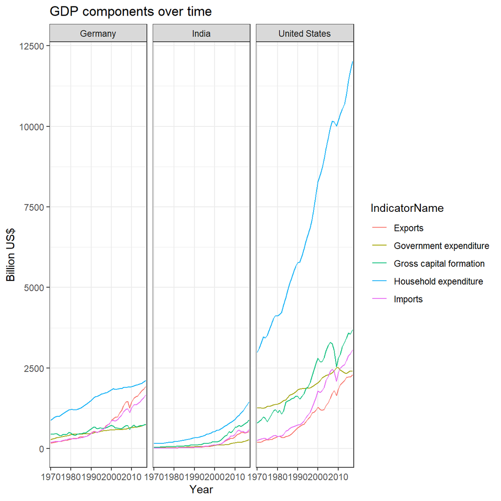

```r
ggplot(tidy_GDP_subset_data, aes(x=Year, y = GDP_components, group = IndicatorName, colour = IndicatorName)) +
  geom_line()+
  facet_wrap(~Country)+
  labs (title = "GDP components over time", x="Year", y="Billion US$") +
  scale_x_discrete(breaks=seq(1970,2017,by=10))+
  theme(axis.text.x = element_text(angle = 45, hjust = 1)) +
  theme_bw()
```

```r
  NULL
```

```r
tidy_GDP_data_1 <- tidy_GDP_data %>%
  filter(IndicatorName == "GDP") %>%
  summarise(Country, GDP_components, Year)

tidy_GDP_data_2 <- tidy_GDP_subset_data %>%
  group_by(Country, Year) %>%
  summarise(sum(GDP_components))

GDP_comparison <- left_join(tidy_GDP_data_2, tidy_GDP_data_1,
  by= (c("Country"="Country", "Year"="Year"))) %>%
  mutate(percentage_diff = (sum(GDP_components)-GDP_components)/GDP_components)

GDP_comparison
```

```
## # A tibble: 144 x 5
## # Groups:   Country [3]
##    Country Year  `sum(GDP_components)` GDP_components percentage_diff
##    <chr>   <fct>                 <dbl>          <dbl>           <dbl>
##  1 Germany 1970                  1956.             NA              NA
##  2 Germany 1971                  2041.             NA              NA
##  3 Germany 1972                  2138.             NA              NA
##  4 Germany 1973                  2224.             NA              NA
##  5 Germany 1974                  2222.             NA              NA
##  6 Germany 1975                  2240.             NA              NA
##  7 Germany 1976                  2376.             NA              NA
##  8 Germany 1977                  2456.             NA              NA
##  9 Germany 1978                  2548.             NA              NA
## 10 Germany 1979                  2692.             NA              NA
## # ... with 134 more rows
```

[figure not shown]

> What is this last chart telling you? Can you explain in a couple of paragraphs the different dynamic among these three countries?

In terms of household expenditure percentage, Germany stays flat at 60% in the given time frame, a bit decreasing after 2000 to nearly 50%; US gradually increases to 70%, while India’s percentage has dropped sharply by 20% between 1980 and 2010 and stayed flat ever since around 55%.

In terms of gross capital formation percentage, Germany decreases from 30% in 1970 to 20% recently. US increases a bit from below 20% to 20%+, while India jumps from 25% in 2000 to 40% in 2010 as a peak, then back to 35% most recently.

In terms of government expenditure percentage, both Germany and India have almost stayed flat in the observation period, at 20% and 10% respectively. However, US has gradually decreased from 25% in 1970 to 15% most recently.

In terms of net exports percentage, both US and India have stayed below 0% in most times while Germany has witnessed an increase since 2000 from zero line to 7% most recently.

# 6 Details